# Projekt 1/1

Rafał Cylwa, Marek Wawreniuk

10 listopada 2016

# Wstęp

Poniżej przedstawiamy implementację gry Super Farmer w języku R przy założeniu, że gra tylko jeden gracz oraz proponowane przez nas strategie gry wraz z implementacją i rozkładami czasu gry.

# Mechanizm gry

## Główna pętla gry

Główna pętla gry posiada jeden argument: - debug - wartość tej zmiennej logicznej mówi nam czy chcemy włączyć tryb debugowania.

```r
gra_1 <- function(debug) {
  wektor_gracza <- c(R = 0, S = 0, P = 0, C = 0, H = 0, SD = 0, BD = 0)
  wektor_stada <- c(R = 60, S = 24, P = 20, C = 12, H = 6, SD = 4, BD = 2)
  kostki <- c(zielona = 'R', czerwona = 'R')
  koniec <- FALSE
  ile <- 0

  while (!koniec) {
    laczny_wektor_gry <- ruch_gracz_yolo(wektor_gracza, wektor_stada)
    wektor_gracza <- laczny_wektor_gry[, 1]
    wektor_stada <- laczny_wektor_gry[, 2]
    koniec <- sprawdz_czy_koniec(wektor_gracza)
    kostki <- rzut_kostkami()
    laczny_wektor_gry <- update_stanu(wektor_gracza, wektor_stada, kostki)
    wektor_gracza <- laczny_wektor_gry[, 1]
    wektor_stada <- laczny_wektor_gry[, 2]
    koniec <- sprawdz_czy_koniec(wektor_gracza)
    ile <- ile + 1
    if (debug == TRUE) {
      print(ile)
      print("")
    }
  }
  return (ile)
}
```

## Funkcje pomocnicze

Lista stworzonych funkcji, obsługujących mechanikę gry.

```r
print(lsf.str())
```

[output not shown]

Oraz ich implementacje:

```r
wektor_czerownej_kostki <- c('R', 'R', 'R', 'R', 'R', 'R', 'S', 'S', 'P', 'P', 'H', 'F')
wektor_zielonej_kostki <- c('R', 'R', 'R', 'R', 'R', 'R', 'S', 'S', 'S', 'P', 'C', 'W')

rzut_jedna_kostka <- function(wektor_wartosci_kostki) {
  return (sample(wektor_wartosci_kostki, 1))
}

rzut_kostkami <- function() {
  zielona <- rzut_jedna_kostka(wektor_zielonej_kostki)
  czerwona <- rzut_jedna_kostka(wektor_czerownej_kostki)
  return(c('zielona' = zielona,'czerwona' =  czerwona))
}

zamien_zwierzaki <- function(stan_gracza, stan_stada, zwierzak, ile) {
#Jeśli ile jest ujemne, to zwierze wraca od gracza do stada głównego
  wartosc_zmiany <- min(stan_stada[zwierzak], ile)
  stan_gracza[zwierzak] <- stan_gracza[zwierzak] + wartosc_zmiany
  stan_stada[zwierzak] <- stan_stada[zwierzak] - wartosc_zmiany
  return (cbind(stan_gracza, stan_stada))
}

update_stanu_zwierze_lagodne <-
  function(stan_gracza, stan_stada, wartosc_kostki, ile_zwierzakow = 1) {
    liczba_naleznych_zwierzakow <- as.integer((stan_gracza[wartosc_kostki] +
                                                 ile_zwierzakow)/2)
    return (zamien_zwierzaki(stan_gracza, stan_stada, wartosc_kostki,
                             liczba_naleznych_zwierzakow))
  }

update_stanu_te_same_wartosci_na_kostkach <-
  function(stan_gracza, stan_stada, wartosc_kostki) {
    return (update_stanu_zwierze_lagodne(stan_gracza, stan_stada,
                                                      wartosc_kostki, 2))
  }

update_stanu_atak_wilka <- function(stan_gracza, stan_stada) {
  for (i in 1:4) {
    wynik_zamienienia <- zamien_zwierzaki(stan_gracza, stan_stada, names(stan_gracza)[i],
                                          (-1)*stan_gracza[names(stan_stada)[i]])
  }
  return (wynik_zamienienia)
}

update_stanu_wilk <- function(stan_gracza, stan_stada) {
  if (stan_gracza['BD'] > 0) {
    return (zamien_zwierzaki(stan_gracza, stan_stada, zwierzak = 'BD', -1))
  } else {
    return (update_stanu_atak_wilka(stan_gracza, stan_stada))
  }
}

update_stanu_atak_lisa <- function(stan_gracza, stan_stada) {
  return (zamien_zwierzaki(stan_gracza, stan_stada, names(stan_gracza)[1],
                                          (-1)*stan_gracza[names(stan_gracza)[1]]))
}

update_stanu_lis <- function(stan_gracza, stan_stada) {
  if (stan_gracza['SD'] > 0) {
    return (zamien_zwierzaki(stan_gracza, stan_stada, zwierzak = 'SD', -1))
  } else {
    return (update_stanu_atak_lisa(stan_gracza, stan_stada))
  }
}

update_stanu_kostka_zielona <- function(stan_gracza, stan_stada, wartosc_kostki) {
  if (wartosc_kostki == 'W') {
    return (update_stanu_wilk(stan_gracza, stan_stada))
  } else {
    return (update_stanu_zwierze_lagodne(stan_gracza, stan_stada, wartosc_kostki))
  }
}

update_stanu_kostka_czerowna <- function(stan_gracza, stan_stada, wartosc_kostki) {
  if (wartosc_kostki == 'F') {
    return (update_stanu_lis(stan_gracza, stan_stada))
  } else {
    return (update_stanu_zwierze_lagodne(stan_gracza, stan_stada, wartosc_kostki))
  }
}

update_stanu_rozne_wartosci_na_kostkach <-
  function(stan_gracza, stan_stada, wartosci_kostki) {
    wynik_pierwszego_updatu <-
      update_stanu_kostka_zielona(stan_gracza, stan_stada, wartosci_kostki['zielona'])
    return (update_stanu_kostka_czerowna(wynik_pierwszego_updatu[,1],
                                         wynik_pierwszego_updatu[,2],
                                         wartosci_kostki['czerwona']))
  }

update_stanu <- function(stan_gracza, stan_stada, wartosci_kostki) {
  if (wartosci_kostki['zielona'] == wartosci_kostki['czerwona']) {
    return (update_stanu_te_same_wartosci_na_kostkach(stan_gracza, stan_stada,
                                                      wartosci_kostki['zielona']))
  } else {
    return (update_stanu_rozne_wartosci_na_kostkach(stan_gracza, stan_stada,
                                                      wartosci_kostki))
  }
}
```

## Funkcja kupowania zwierzęcia przez gracza

```r
kup_zwierze_yolo <- function(jakie_zwierze, wektor_gracza, wektor_stada) {
  wartosc_zwierzat <- c(R = 1, S = 6, P = 12, C = 36, H = 72, SD = 6, BD = 36)
  wektor_wymiany <- c(R = 0, S = 0,  P = 0, C = 0, H = 0, SD = 0, BD = 0)
  suma <- 0
  zwierze <- 1
  ile_zwierzat <- 1
  i <- 1
  koniec <- FALSE
  while(i < jakie_zwierze && koniec == FALSE) {
    if(wektor_gracza[i] != 0){
      for(j in 1:wektor_gracza[i]) {
        if(suma >= wartosc_zwierzat[jakie_zwierze]) {
          koniec <- TRUE
          break
        }
        suma = suma + wartosc_zwierzat[i]
        zwierze <- i
        ile_zwierzat <- j
      }
    }
    i <- i+1
  }
  #tworzymy wektor do wymiany
  for(i in 1:zwierze) {
    wektor_wymiany[i] <- wektor_gracza[i]
  }
  wektor_wymiany[zwierze] <- ile_zwierzat
  wektor_wymiany[1] <- wektor_wymiany[1] - (suma - wartosc_zwierzat[jakie_zwierze]) #oddajem namiarowe kroliki
  wektor_gracza <- wektor_gracza - wektor_wymiany
  wektor_stada <- wektor_stada + wektor_wymiany
  wektor_gracza[jakie_zwierze] = wektor_gracza[jakie_zwierze] + 1
  wektor_stada[jakie_zwierze] = wektor_stada[jakie_zwierze] - 1

  return(cbind(wektor_gracza,wektor_stada))
}
```

# Opis strategii

## Strategia 1: “YOLO”

Strategia “YOLO” polega na bezmyślnym kupowaniu zwierząt o jak najwyższej wartości kiedy tylko się da. Jej istota polega na tym, że gracz w ogóle nie zwraca sobie głowy psami obronnymi. Taktyka ta pozwala na szybkie zakończenie gry, ale jest obarczona niemałym ryzykiem.

```r
ruch_gracz_yolo <- function(wektor_gracza, wektor_stada) {
  #znajdujemy najstarsze zwierze, ktorego nie mamy i staramy sie je kupic
  i <- 5
  wartosc_zwierzat <- c(R = 1, S = 6, P = 12, C = 36, H = 72, SD = 6, BD = 36)
  while(i > 1) {
    if(wektor_gracza[i] == 0 && sum(wektor_gracza[1:(i - 1)]*wartosc_zwierzat[1:(i - 1)]) >= wartosc_zwierzat[i])
    {
      zakup <- kup_zwierze_yolo(i, wektor_gracza, wektor_stada)
      return(zakup)
    }
    i <- i-1
  }
  return(cbind(wektor_gracza, wektor_stada))
}
```

## Strategia 2: “ANTY-YOLO”

“ANTY-YOLO” polega na tym, że gracz boi się zagrożeń. Jego głównym celem podczas gry będzie zakup obu psów. Dopiero posiadając oba zwierzaki, zaczyna grać jak gracz “YOLO”, ponieważ się już nie boi. W sytuacji gdy któryś pies wraca do głownego stada, “ANTY-YOLO” jest skupiony tylko i wyłącznie na zakupie brakującego zwierzęcia obronnego.

```r
czy_gracz_ma_oba_psy <- function (stan_gracza) {
  return (stan_gracza['SD']*stan_gracza['BD'] > 0)
}

zakup_zwierzecia <- function(stan_gracza, stan_stada, zwierzak) {
  wartosci_zwierzat <- c(R = 1, S = 6, P = 12, C = 36, H = 72, SD = 6, BD = 36)
  if (sum(stan_gracza[1:5]*wartosci_zwierzat[1:5]) >= wartosci_zwierzat[zwierzak]) {
    return (kup_zwierze_yolo(zwierzak, stan_gracza, stan_stada))
  } else {
    return (cbind(stan_gracza, stan_stada))
  }
}

ruch_gracz_anty_yolo_zakup_malego_psa <- function(stan_gracza, stan_stada) {
  return (zakup_zwierzecia(stan_gracza, stan_stada, 6))
}

ruch_gracz_anty_yolo_zakup_duzego_psa <- function(stan_gracza, stan_stada) {
  return (zakup_zwierzecia(stan_gracza, stan_stada, 7))
}

ruch_gracz_anty_yolo_zakup_psow <- function (stan_gracza, stan_stada) {
  if (stan_gracza['SD'] == 0) {
    return (ruch_gracz_anty_yolo_zakup_malego_psa(stan_gracza, stan_stada))
  } else { #skoro mały pies jest w stadzie gracza, a jesteśmy w tej funkcji
           #to w stadzie gracza nie ma dużego psa
    return (ruch_gracz_anty_yolo_zakup_duzego_psa(stan_gracza, stan_stada))
  }
}

ruch_gracz_anty_yolo <- function (stan_gracza, stan_stada) {
  if (czy_gracz_ma_oba_psy(stan_gracza)) {
    return (ruch_gracz_yolo(stan_gracza, stan_stada))
  } else {
    return (ruch_gracz_anty_yolo_zakup_psow(stan_gracza, stan_stada))
  }
}
```

Powyższa taktyka jest nieoptymalna ze względu na to, że wczesny zakup owych psów znacząco spowalnia tempo rozmnażania ilości zwierząt w stadzie.

## Strategia 3: “ANTY-YOLO-N-YOLO”

Ten sposób gry jest połączeniem obu wyżej. Gracz z góry sobie ustala ilość (n) zakupionych przez siebie psów obronnych. Dopóki nie zakupił w trakcie gry podanej ilości psów, gra on taktyką “ANTY-YOLO”, jednak po przekroczeniu owej liczby kieruje się zasadami gracza “YOLO”.

Taktyka wymiana zmiany kodu funkcji gra(), gdyż po każdym ruchu sprawdzamy czy został zakupiony któryś z psów. W tym celu zaimplementowana została funkcja aktualizująca wartość n.

```r
n_anty_yolo_yolo_zmiana <- function (wartosc1, wartosc2, n) {
  if (wartosc2 - wartosc1 == 1) {
    return (n - 1)
  } else {
    return (n)
  }
}
###########################################################################
#W FUNKCJI gra() MUSIMY AKTUALIZOWAC WARTOSC N I ROBIMY TO W TEN SPOSÓB   #
#n <- n_anty_yolo_yolo_zmiana(ile_psow_przed_ruchem, ile_psow_po_ruchu, n)#
###########################################################################
ruch_gracz_anty_yolo_n_yolo <- function (w_gracza, w_stada, n) {
  if (n > 0) {
    return (ruch_gracz_anty_yolo(w_gracza, w_stada))
  } else {
    return (ruch_gracz_yolo(w_gracza, w_stada))
  }
}
```

## Strategia 4: “ANTY-YOLO-N-YOLO-K-RABBITS”

Ten sposób gry to rozszerzenie “ANTY-YOLO-N-YOLO”, które sprawdza dodatkowo ile mamy królików w stadzie. Założenie jest takie, że nie do końca opłaca się kupować psy od razu kiedy je na nas stać, robimy to dopiero kiedy mamy w stadzie zwierzęta o wartości większej niż k królików.

```r
ruch_gracz_anty_yolo_n_yolo_k_rabbits <- function (w_gracza, w_stada, n, k) {
  wartosc_zwierzat <- c(R = 1, S = 6, P = 12, C = 36, H = 72, SD = 6, BD = 36)
  aktualna_liczba_krolikow <- sum(w_gracza[1:5]*wartosc_zwierzat[1:5])
  if (aktualna_liczba_krolikow < k) {
    return (ruch_gracz_yolo(w_gracza, w_stada))
  } else {
    return (ruch_gracz_anty_yolo_n_yolo(w_gracza, w_stada, n))
  }
}
```

# Symulacje

Porównanie rozkładów czasu gry poszczególnych strategii.

```r
library(ggplot2)
czasy_gry_1 <- replicate(10000, gra_1(debug = FALSE))
czasy_gry_2 <- replicate(10000, gra_2())
czasy_gry_3 <- replicate(10000, gra_3())
czasy_gry_4 <- replicate(10000, gra_4())
```

## Strategia 1: “YOLO”

Średnia:

```r
mean(czasy_gry_1)
```

```
## [1] 61.7574
```

```r
length(czasy_gry_1)
```

```
## [1] 10000
```

Mediana

```r
median(czasy_gry_1)
```

```
## [1] 55
```

Rozkład:

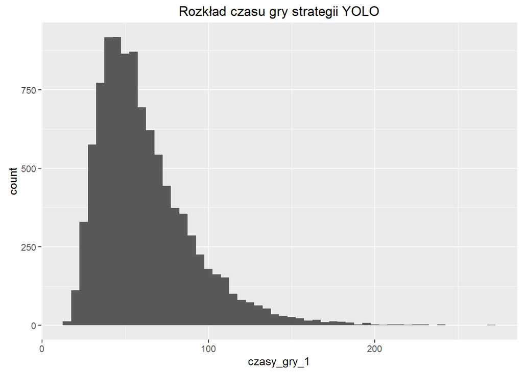

```r
qplot(czasy_gry_1, geom = "histogram", binwidth = 5, main = "Rozkład czasu gry strategii YOLO")
```

## Strategia 2: “ANTY-YOLO”

Średnia:

```r
mean(czasy_gry_2)
```

```
## [1] 74.0813
```

Mediana

```r
median(czasy_gry_2)
```

```
## [1] 67
```

Rozkład:

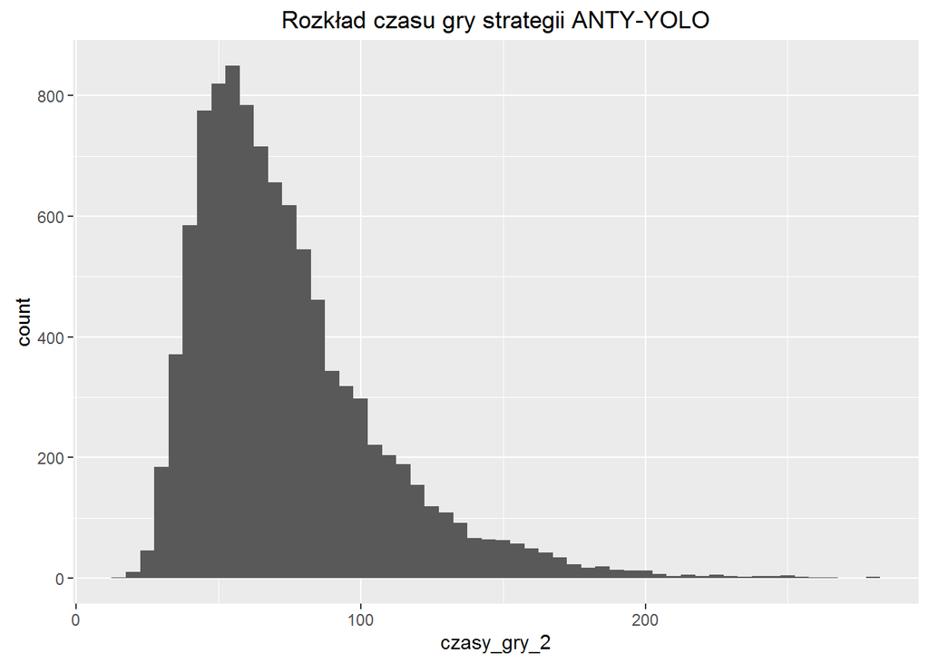

```r
qplot(czasy_gry_2, geom = "histogram", binwidth = 5, main = "Rozkład czasu gry strategii ANTY-YOLO")
```

## Strategia 3: “ANTY-YOLO-N-YOLO”

Średnia:

```r
mean(czasy_gry_3)
```

```
## [1] 69.2141
```

Mediana

```r
median(czasy_gry_3)
```

```
## [1] 64
```

Rozkład:

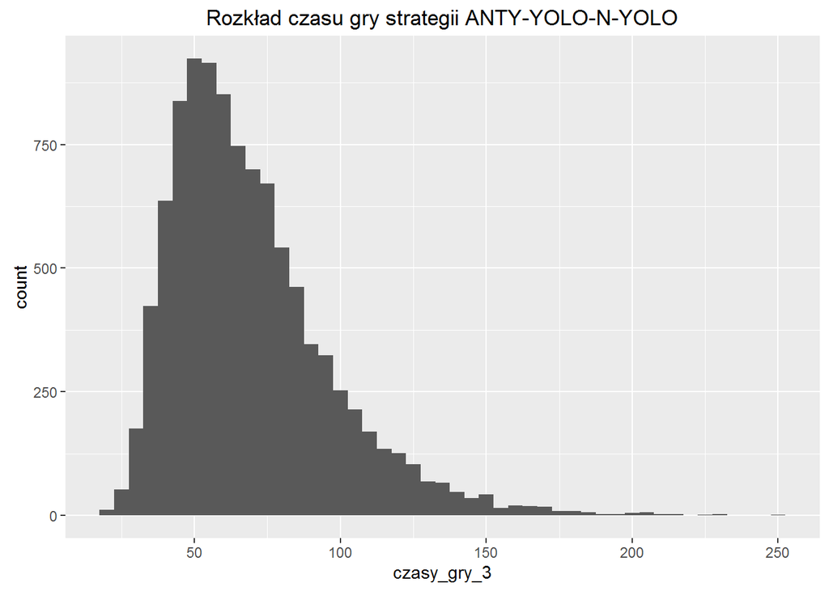

```r
qplot(czasy_gry_3, geom = "histogram", binwidth = 5, main = "Rozkład czasu gry strategii ANTY-YOLO-N-YOLO")
```

## Strategia 4: “ANTY-YOLO-N-YOLO-K-RABBITS”

Średnia:

```r
mean(czasy_gry_4)
```

```
## [1] 63.4262
```

Mediana

```r
median(czasy_gry_4)
```

```
## [1] 57
```

Rozkład:

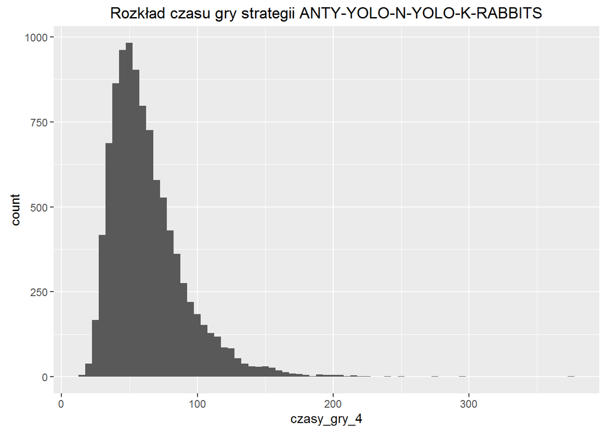

```r
qplot(czasy_gry_4, geom = "histogram", binwidth = 5, main = "Rozkład czasu gry strategii ANTY-YOLO-N-YOLO-K-RABBITS")
```